# CENSUS 2021: Housing

The [CENSUS 2021](https://census.gov.uk) in England and Wales published data about [housing](https://www.ons.gov.uk/releases/housingcensus2021inenglandandwales). The release included three publications: [People with second addresses](https://www.ons.gov.uk/peoplepopulationandcommunity/housing/bulletins/peoplewithsecondaddressesenglandandwales/census2021), [Housing](https://www.ons.gov.uk/peoplepopulationandcommunity/housing/bulletins/housingenglandandwales/census2021) and [Communal establishment residents](https://www.ons.gov.uk/peoplepopulationandcommunity/housing/bulletins/communalestablishmentresidentsenglandandwales/census2021).

## Central Heating

In Trafford, 98.8% (95,107) of households have central heating whilst the remaining 1.2% (1,160) of households do not have central heating. The most common type of central heating in Trafford’s households is by far “Mains gas only” (81.9%, 78,873).

In Trafford, 139 (0.1%) households have a central heating that only uses renewable energy. An additional 217 households (0.2%) use renewable energy alongside other type of central heating.

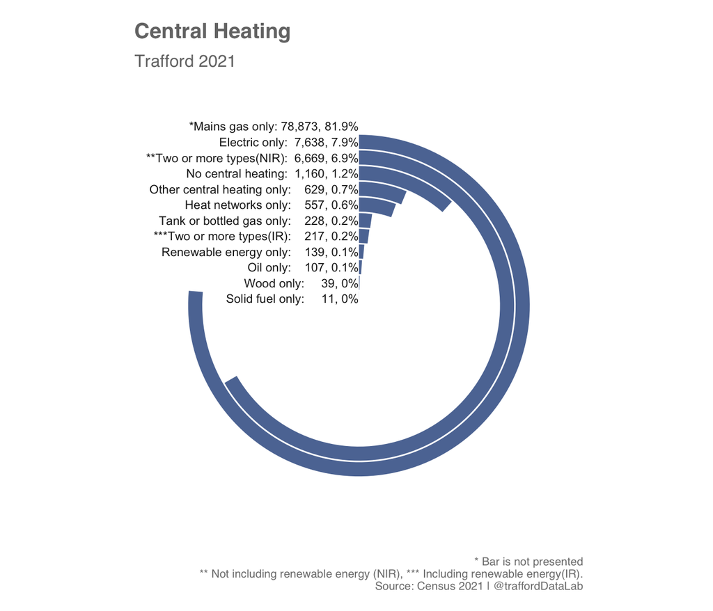

Trafford has a higher proportion of households with “Mains gas only” central heating, When compared to the mean of 15 similar authorities, Greater Manchester and England. For most of all other central heating categories, the proportion of households in Trafford is lower when compared to the mean of similar authorities, Greater Manchester and England.

Trafford has a 0.3 % of households using at least one renewable energy source for central heating, while the mean of similar authorities is more than the double at 0.7% and England’s percentage (0.9%) is three times that of Trafford.

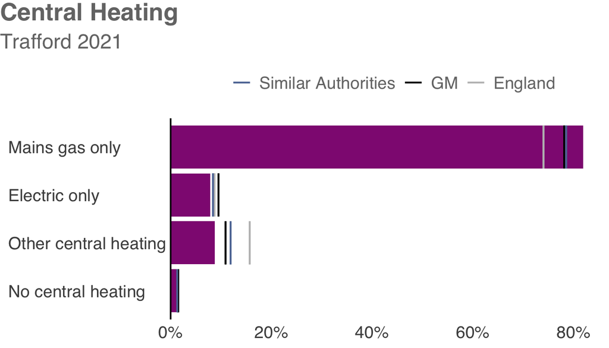

|  | Trafford | Similar Authorities | Greater Manchester | England |
| --- | --- | --- | --- | --- |
| Mains gas only | 81.9% | 78.5% | 78.1% | 74% |
| Electric only | 7.9% | 8.4% | 9.5% | 8.7% |
| Other central heating | 8.8% | 11.9% | 10.9% | 15.7% |
| No central heating | 1.2% | 1.3% | 1.5% | 1.5% |

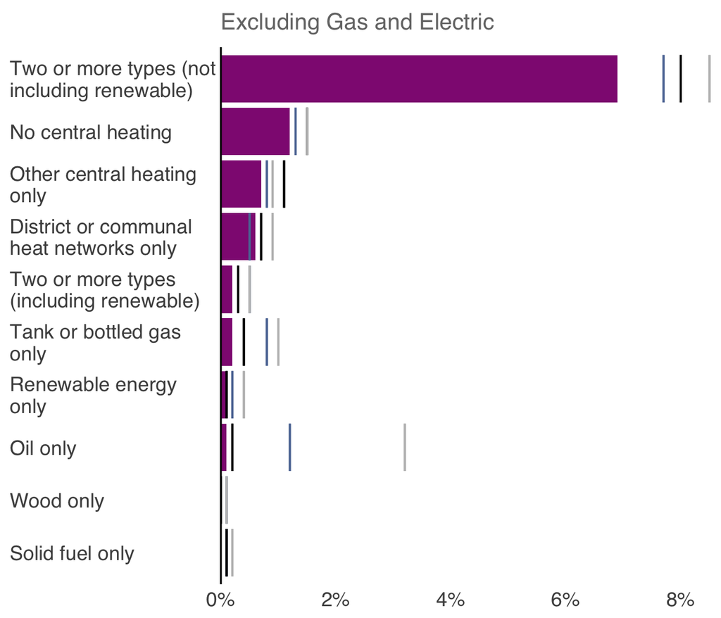

|  | T* | S A* | GM* | E* |
| --- | --- | --- | --- | --- |
| Two or more types (not including renewable) | 6.9% | 7.7% | 8% | 8.5% |
| No central heating | 1.2% | 1.3% | 1.5% | 1.5% |
| Other central heating only | 0.7% | 0.8% | 1.1% | 0.9% |
| District or communal heat networks only | 0.6% | 0.5% | 0.7% | 0.9% |
| Two or more types (including renewable) | 0.2% | 0.5% | 0.3% | 0.5% |
| Tank or bottled gas only | 0.2% | 0.8% | 0.4% | 1% |
| Renewable energy only | 0.1% | 0.2% | 0.1% | 0.4% |
| Oil only | 0.1% | 1.2% | 0.2% | 3.2% |
| Wood only | 0% | 0.1% | 0% | 0.1% |
| Solid fuel only | 0% | 0.1% | 0.1% | 0.2% |

T* = Trafford, S A* = Similar Authorities (CIPFA 2021), GM* = Greater Manchester and E* = England

The Trafford’s MSOAs with the highest proportion of households with No central heating was Old Trafford with 2.1% (100 households) Gorse Hill with 1.9% (70 households), Partington with 1.8% (60 households) and Sale Central with 1.7% (73 households).

[interactive chart not shown]

## Bedroom occupancy

The Bedroom occupancy rating measure whether a household’s accommodation is overcrowded, ideally occupied or under-occupied. This is calculated by comparing the number of bedrooms the household requires to the number of available bedrooms according to the Bedroom Standard.

An occupancy rating of -1 or less implies that a household’s accommodation has fewer bedrooms than required (overcrowded). Likewise, an occupancy rating of +1 or more implies that a household’s accommodation has more bedrooms than required (under-occupied). And finally, an occupancy rating of 0 suggests that a household’s accommodation has an ideal number of bedrooms.

According to the Census 2021, 73.5% (70,746) of households in Trafford were under-occupied and 2.9% (2,779) were overcrowded. Trafford had a higher proportion of under-occupied households when compared to the average of 15 similar local authorities, Greater Manchester and England. In contrast, Trafford had a lower proportion of overcrowded households than the average of 15 similar local authorities, Greater Manchester and England.

The MSOAs with a higher proportion of households living in overcrowded properties are Old Trafford and Firswood with 9.9% (473) and 7.3% (224) of households respectively. Old Trafford had 1.8% (86) of households requiring 2 or more bedrooms to achieve ideal occupancy.

In contrast, more than a third of Trafford’s MSOAs had over 80% of households living in under-occupied properties. Timperley South, Bowdon, Hale, Ashton upon Mersey South, Timperley North and Hale Barns had over 50% of households living in properties with 2 or more spare rooms.

[interactive chart not shown]

## Tenure

According to the Census 2021, 69% (66,387) of households in Trafford own the house they live in, 15.3% (14,744) rent privately, and 15% (14,419) rent their house from a social landlord.

In 2021, Trafford had a larger proportion of households that owned the house they lived in when compared to the average of 15 similar local authorities as well as Greater Manchester and England. This applies to both types of ownership: with a mortgage or loan, and outright.

Consequently, Trafford had a lower proportion of households that rented the house they lived in, when compared to the average of 15 similar local authorities, Greater Manchester and England.

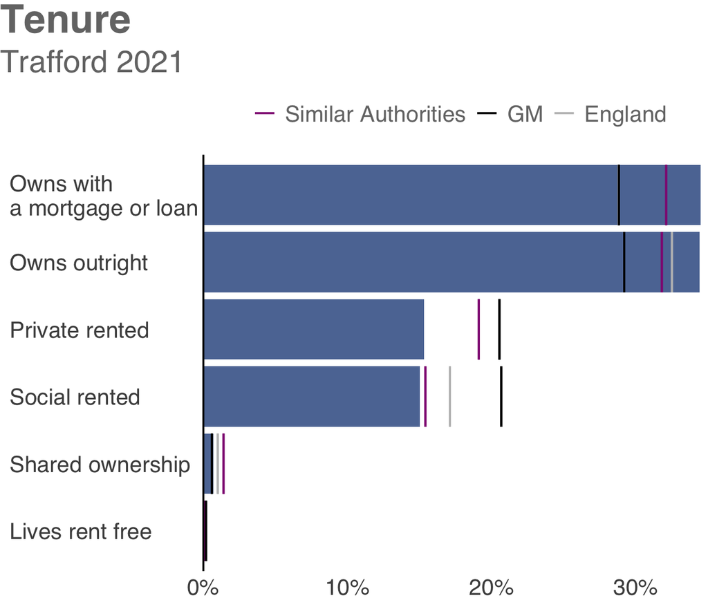

|  | Trafford | Similar Authorities | Greater Manchester | England |
| --- | --- | --- | --- | --- |
| Owns with a mortgage or loan | 34.5% (33,238) | 32.1% | 28.82% | 28.8% |
| Owns outright | 34.4% (33,149) | 31.8% | 29.19% | 32.5% |
| Private rented | 15.3% (14,744) | 19.1% | 20.54% | 20.5% |
| Social rented | 15% (14,419) | 15.4% | 20.66% | 17.1% |
| Shared ownership | 0.7% ( 654) | 1.4% | 0.59% | 1% |
| Lives rent free | 0.1% ( 65) | 0.1% | 0.19% | 0.1% |

### Mortgage payers and private renters

[interactive chart not shown]